# RWC x LFM

Indra Boving

10/24/2021

# Section 1: Pressure Volume Curves

### 1.1: Variation in TLPs

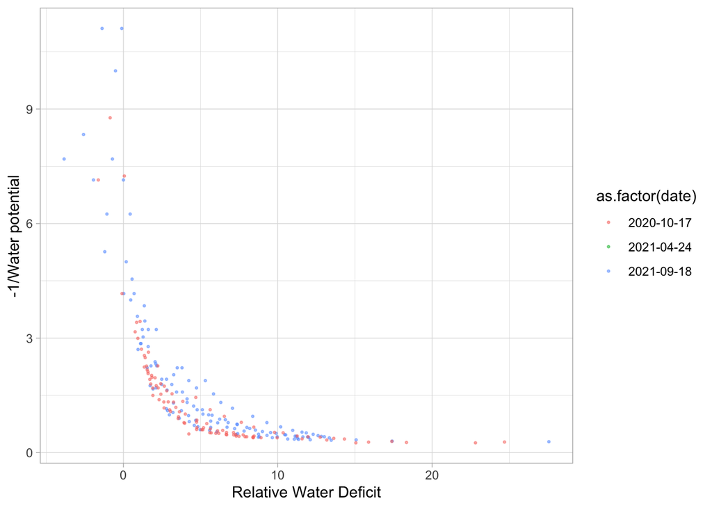

1. In fall and spring: (fall both sampling dates combined)

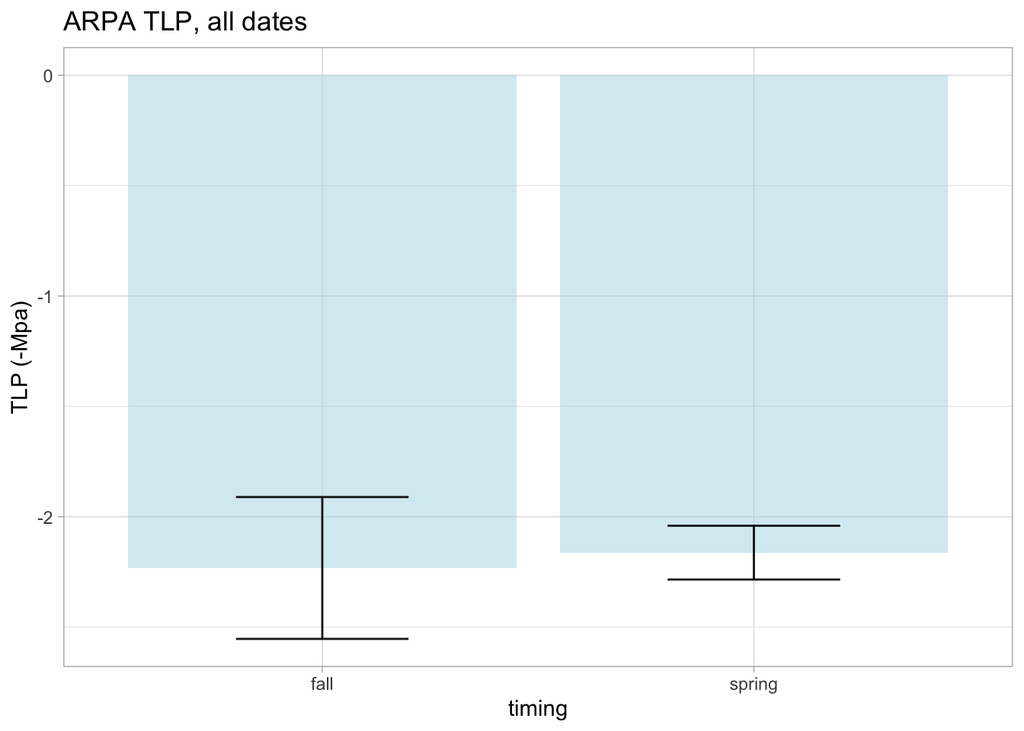

No significant difference betwwen TLPs of different dates (p > 0.1)

2. Fall dates:

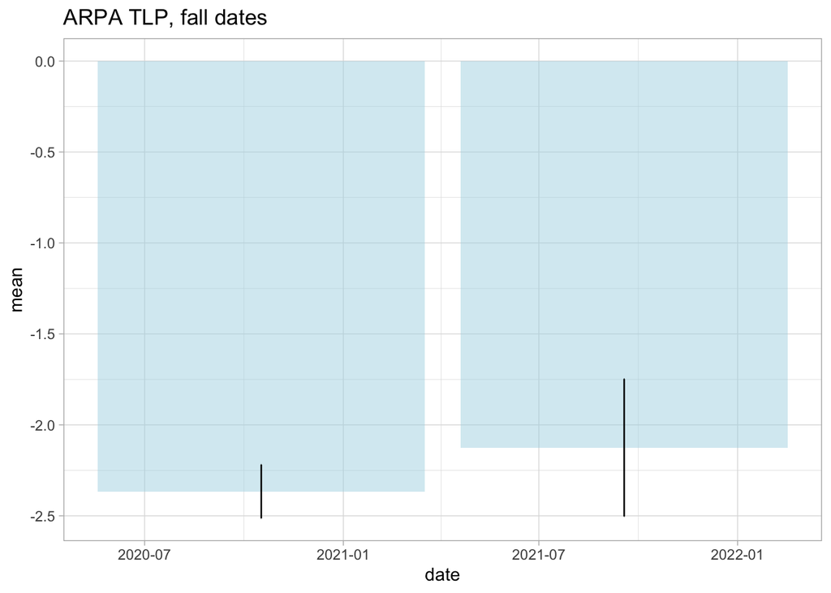

### 1.2: Try to predict Mpa from LFM with just one species

1. Get datasets in order:
- select for just the species and date we are interested in
- remove any anomalous curves
- pull the TLP as a value
- make two sub-datasets: one for all points above the TLP, one for all points below the TLP

For fall PV curves, the mean TLP = -2.2, sd = 0.34

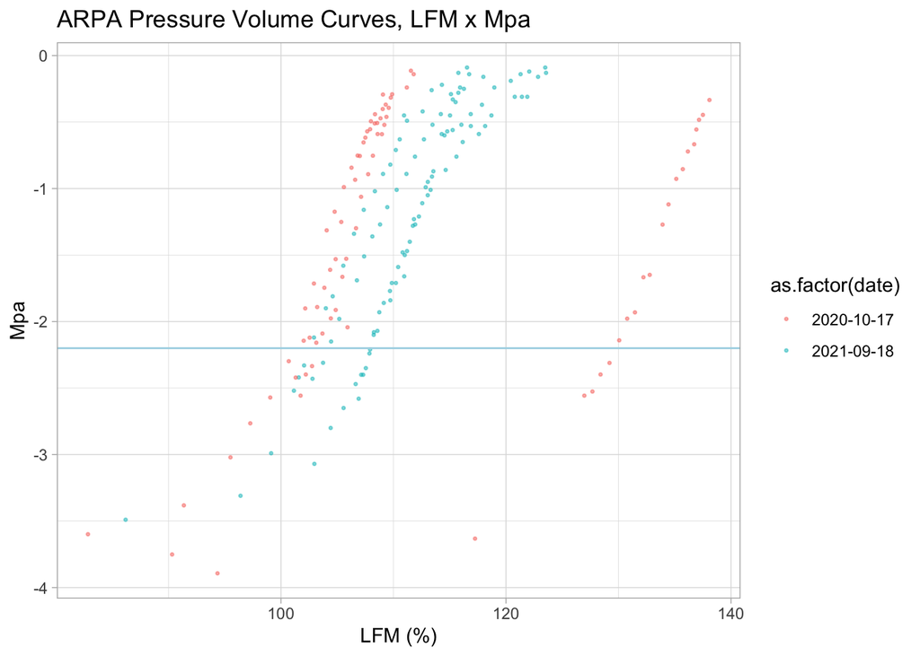

2. For points below the TLP, there should be a linear relationship between -1/Mpa and LFM

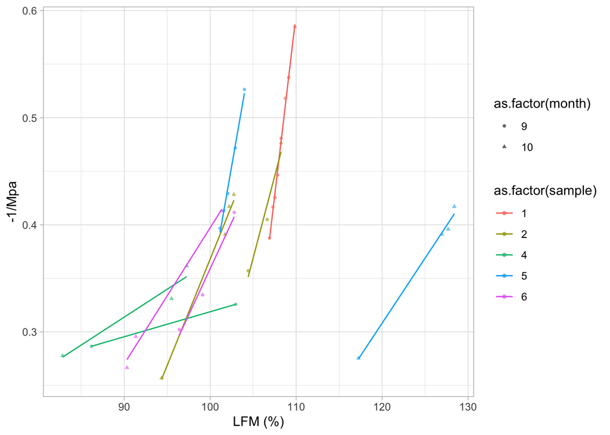

3. For points above the TLP, there should be a linear relationship between Mpa and lfm

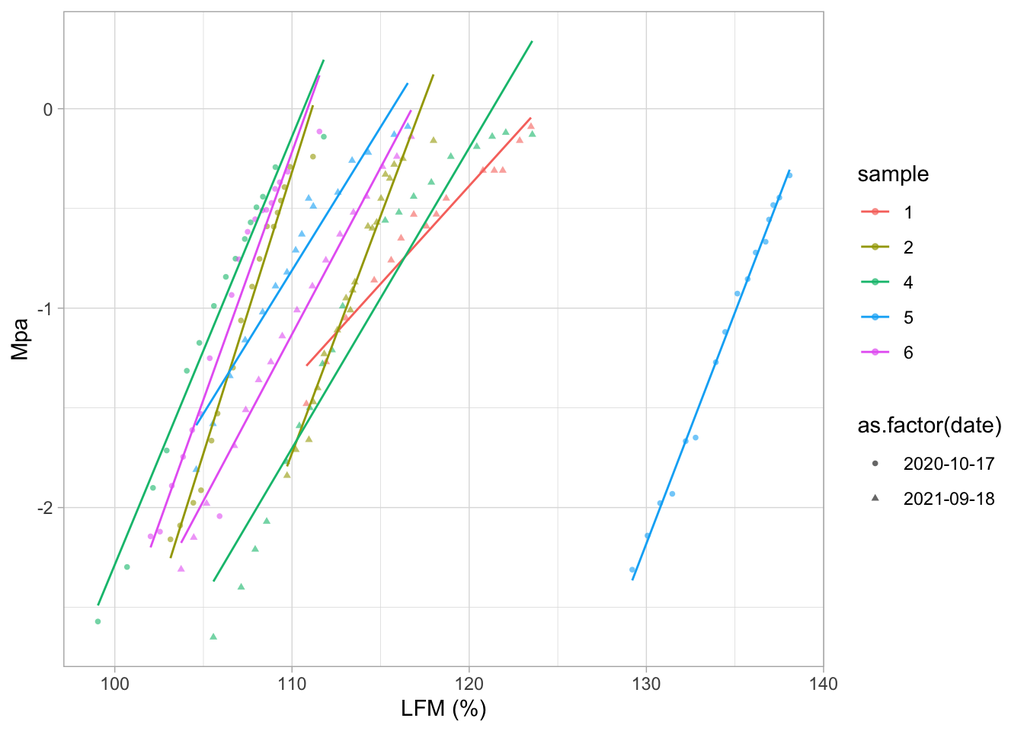

We have some linear models that should be able to predict Mpa from LFM. Now, to test it out…

# Section 2: Can we predict actual values using the models built from the PV curves?

## 2.1: Flam-curve values

- Read in flam curve data
- Use `predict()` to see if we can use PV curve models to get values collected during flammability curve testing.

$$\operatorname{-1/water\_potential} = \alpha + \beta_{1}(\operatorname{lfm}) + \epsilon$$
$$\operatorname{water\_potential} = \alpha + \beta_{1}(\operatorname{lfm}) + \epsilon$$

We’re just interested in ARPA, so just look there:

### Below TLP:

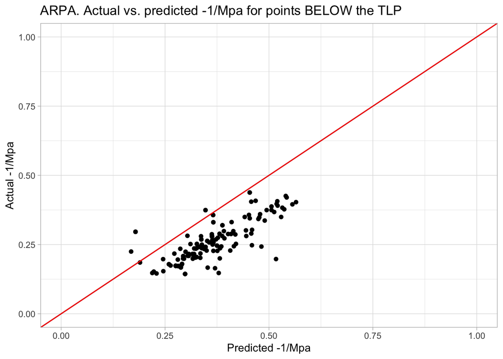

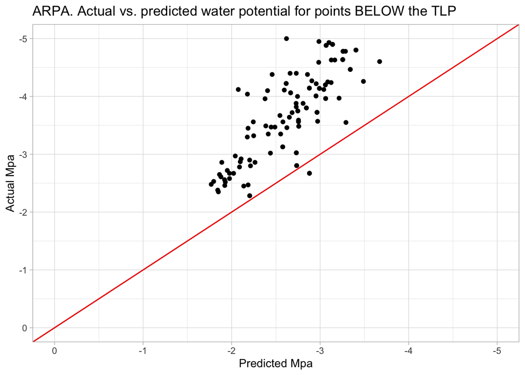

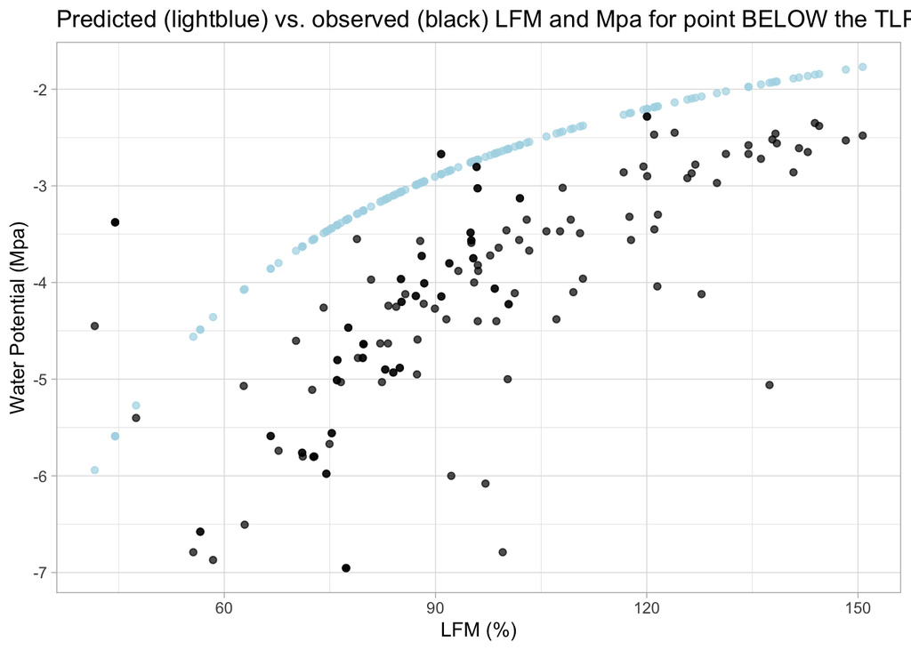

### Above TLP:

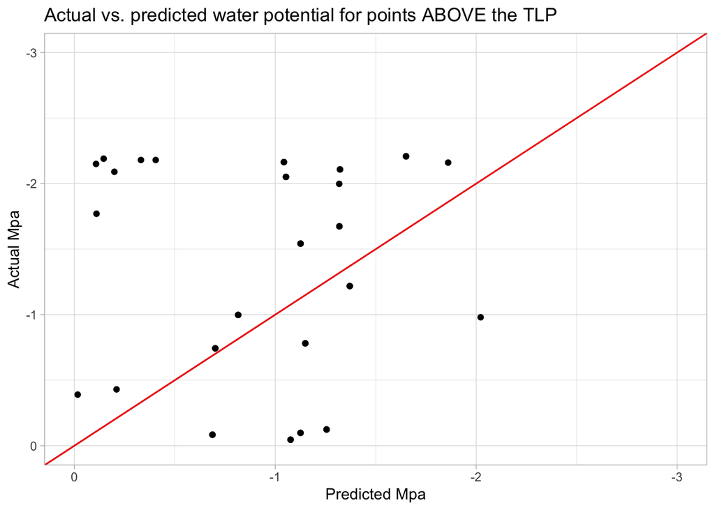

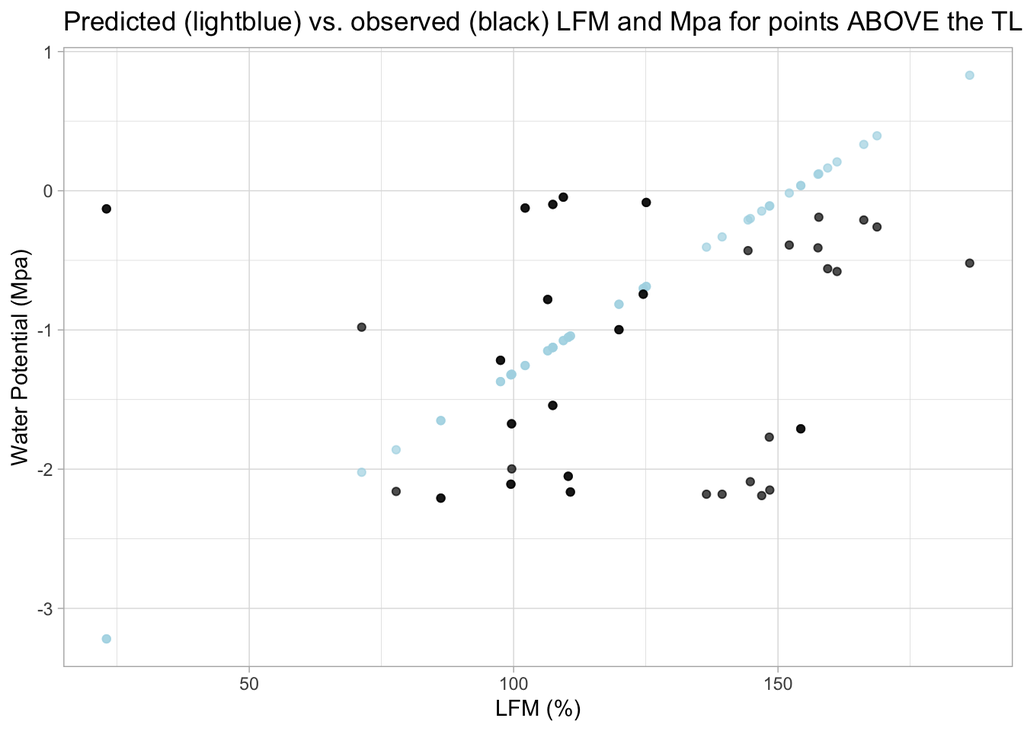

## 2.2: Field data

- Use `predict()` to see if we can use PV curve models to get values collected in the field (predict midday Mpa from LFM):

We’re just interested in ARPA, so just look there:

### Below TLP:

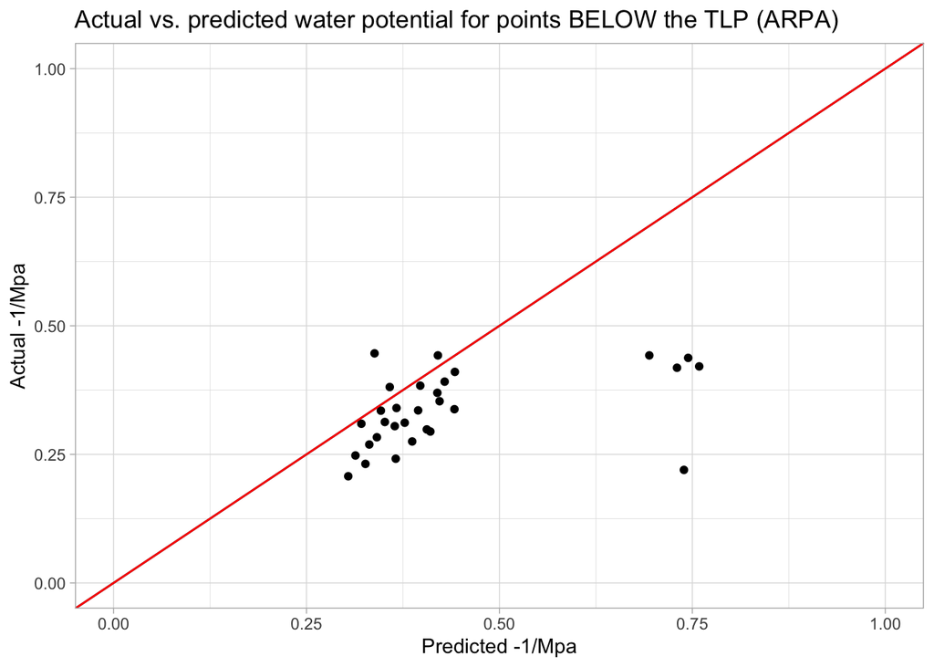

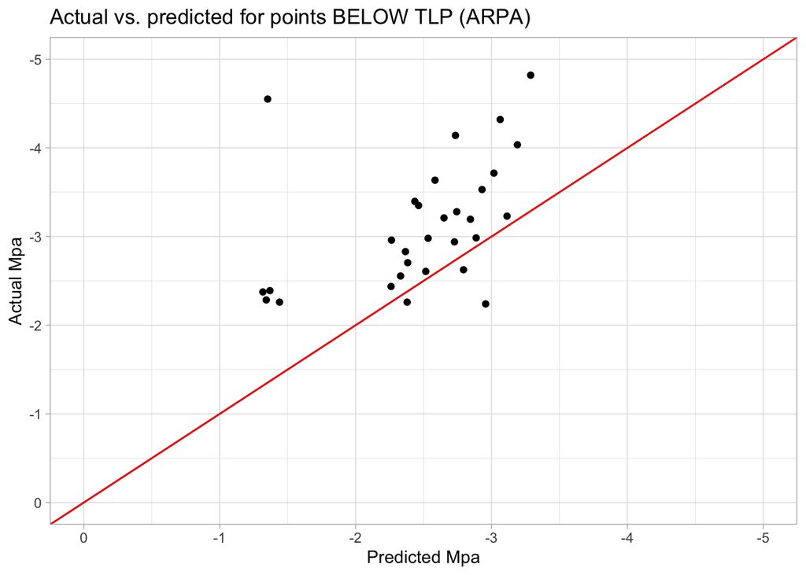

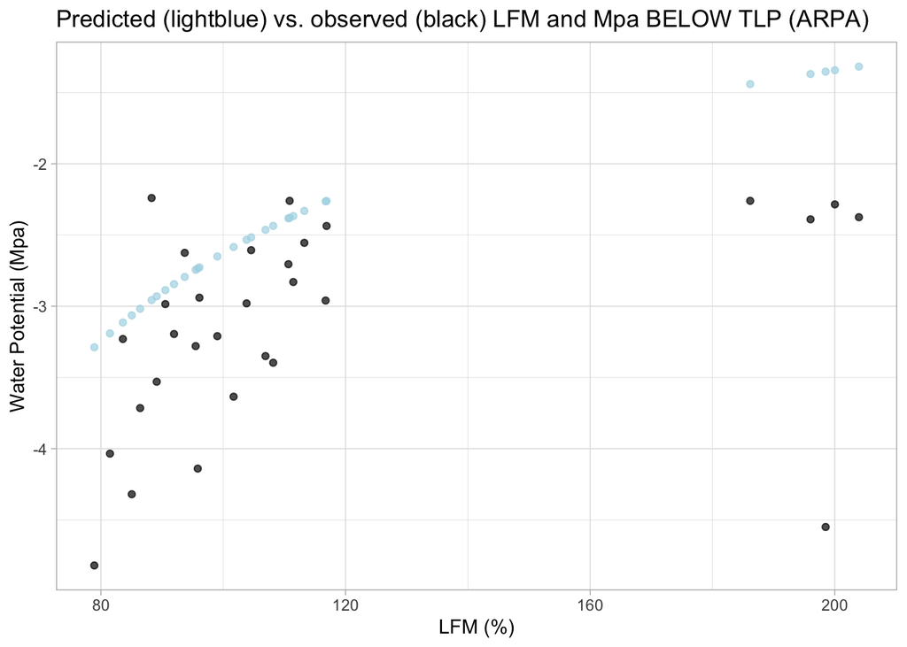

### Above TLP:

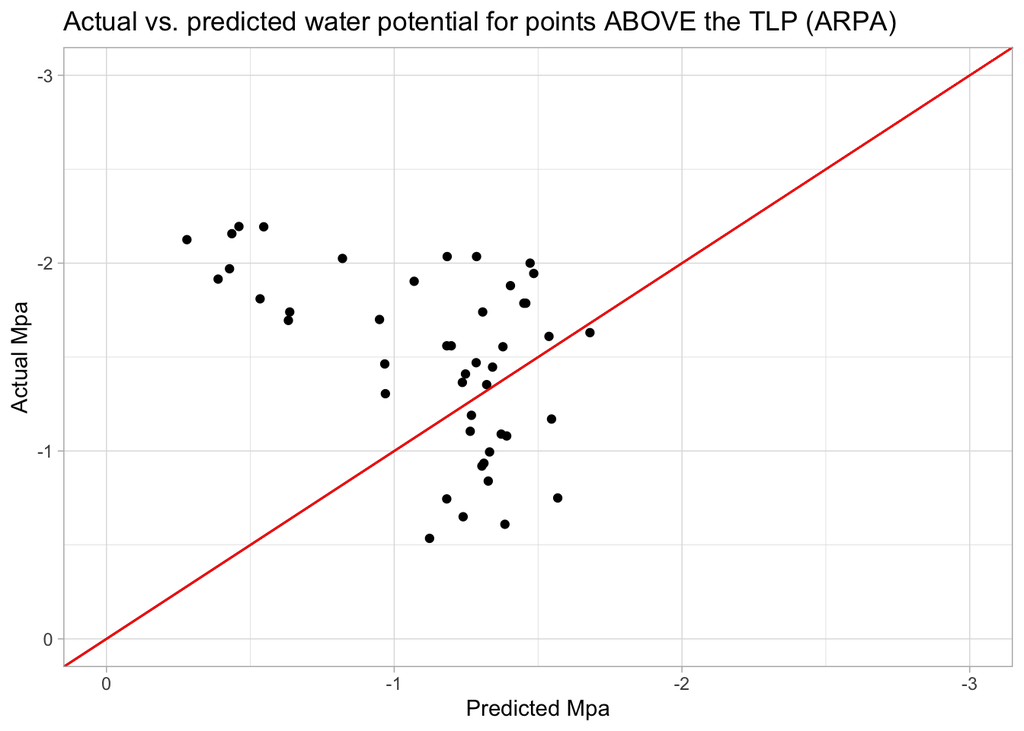

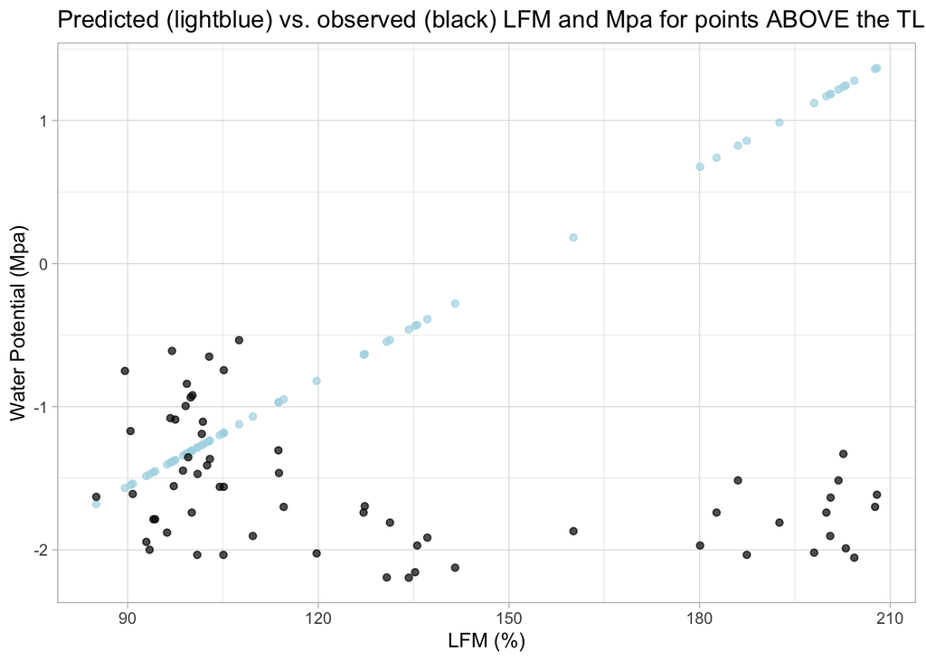